# Assignment 8: Visualization - Making a bar race

*How to do it?*:

- Open the Rmarkdown file of this assignment (link) in Rstudio.
- Right under each **question**, insert a code chunk (you can use the hotkey `Ctrl + Alt + I` to add a code chunk) and code the solution for the question.
- `Knit` the rmarkdown file (hotkey: `Ctrl + Alt + K`) to export an html.
- Publish the html file to your Githiub Page.

*Submission*: Submit the link on Github of the assignment to Canvas

1. Install two packages `gganimate` and `gifski` then restart Rstudio. Using the `Adult Census Income` data, make an animation using `geom_point` and `transition_states`.

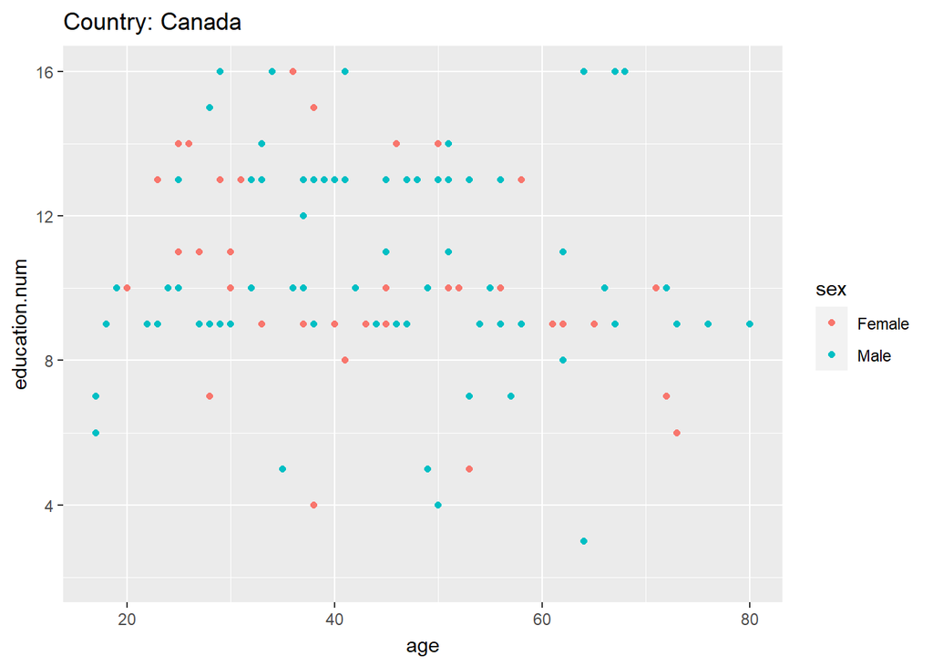

```r
library(tidyverse)
library(gganimate)
df <- read_csv('https://bryantstats.github.io/math421/data/adult_census.csv')

df %>%
  filter(native.country %in% c('United States', 'Italy', 'Canada', 'Japan')) %>%
  ggplot(aes(x=age, y = education.num, color = sex))+geom_point()+
  transition_states(native.country)+labs(title = 'Country: {closest_state}')
```

2. Using the `Adult Census Income` data, make an animation using `geom_bar` and `transition_states`.

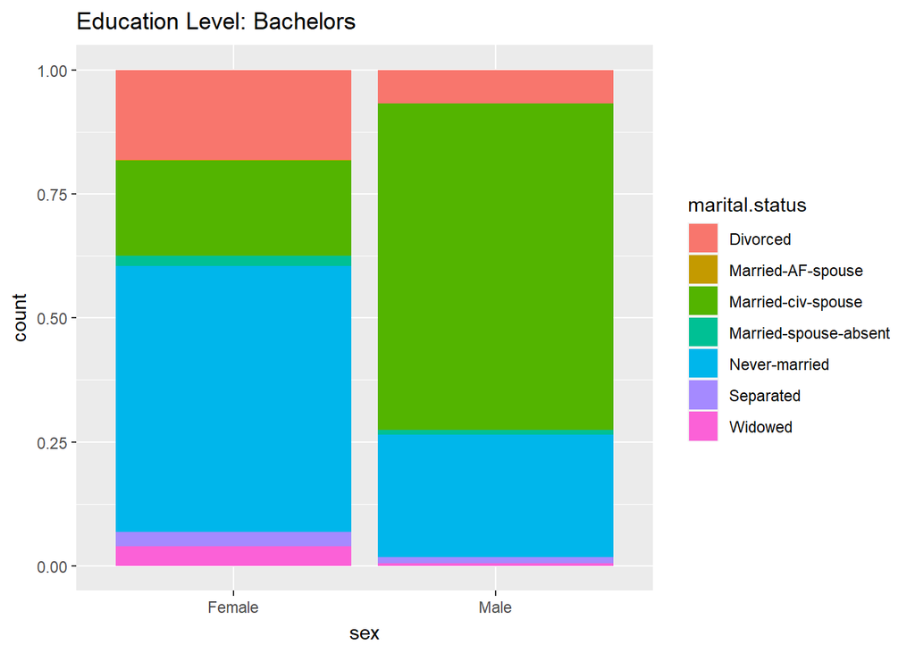

```r
df %>%
  filter(education %in% c('Some-college', 'Bachelors', 'Masters', 'Doctorate')) %>%
  ggplot(aes(x=sex, fill = marital.status))+geom_bar(position = 'fill') + transition_states(education) + labs(title = 'Education Level: {closest_state}')
```

3. Use the WHO’s dataset at [this link](https://covid19.who.int/WHO-COVID-19-global-data.csv). Make a top-10 bar race by months between countries on the number of deaths by Covid 19 in 2021.

[figure not shown]

```r
library(gapminder)
library(gganimate)
library(ggplot2)
library(tidyverse)
library(lubridate)
library(knitr)
df <- read_csv('https://covid19.who.int/WHO-COVID-19-global-data.csv')
df$month <- month(df$Date_reported)

df1 <- df %>%
filter(Date_reported >='2021-01-01', Date_reported < '2022-01-01')


d1 <- df1 %>% group_by(month, Country) %>% summarise(mean = mean(New_deaths))

d2 <- d1 %>% group_by(month) %>% mutate(rank=rank(-mean))
d3 <- d2 %>% filter(rank <= 10)

a1 <- d3 %>% ggplot(aes(x=rank, y=mean, group=Country, fill=Country, label=Country)) + geom_col()+
    geom_text(aes(y = mean, label = Country), hjust = 1.4)+
    coord_flip(clip = "off", expand = FALSE) +scale_x_reverse()+
    labs(title = 'Month {closest_state}', x='', y='Total Number of Positive Caeses', fill='Country')+
    theme(plot.title = element_text(hjust = 1, size = 22),
          axis.ticks.y = element_blank(),
          axis.text.y  = element_blank()) +
    transition_states(month)+
    ease_aes("cubic-in-out")
animate(a1, nframes = 400)
```

4. Make a bar race using a dataset of your own interest. You may use the dataset that we use in class (https://covidtracking.com/data/download/all-states-history.csv) but you should make a different bar race from ones in the slides.

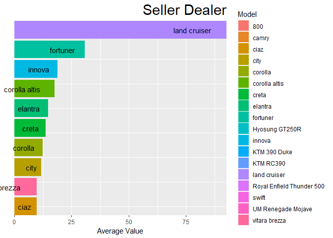

```r
setwd("C:/Users/student/Documents/Stat Analysis with R/MATH421")
df <- read_csv('car data.csv')

d1 <- df %>% group_by(Seller, Model) %>% summarise(mean = mean(Value))

d2 <- d1 %>% group_by(Seller) %>% mutate(rank=rank(-mean))
d3 <- d2 %>% filter(rank <= 10)

a1 <- d3 %>% ggplot(aes(x=rank, y=mean, group=Model, fill=Model, label=Model)) + geom_col()+
    geom_text(aes(y = mean, label = Model), hjust = 1.4)+
    coord_flip(clip = "off", expand = FALSE) +scale_x_reverse()+
    labs(title = 'Seller {closest_state}', x='', y='Average Value', fill='Model')+
    theme(plot.title = element_text(hjust = 1, size = 22),
          axis.ticks.y = element_blank(),
          axis.text.y  = element_blank()) +
    transition_states(Seller)+
    ease_aes("cubic-in-out")
animate(a1, nframes = 400)
```